# Peer Assessment 1

Abirvab Deb

Friday, October 17, 2014

## Loading and preprocessing

##### Loading data into a data frame

```r
con <- file("activity.csv","r")
data <- read.csv(con, header=TRUE)
close(con)
```

## What is the mean total number of steps taken per day?

#### Computing the number of intervals recorded each day

The **while loop** in this code chunk iterates until interval 0 is reached again and *count* keeps track of all the intervals.

```r
count=2
num=data$interval[count]
while(num != data$interval[1]){
        count=count+1
        num=data$interval[count]
}
count=count-1
```

#### Computing the total number of steps taken per day

Using a *for loop* in this code chunk to iterate through the data frame and summing cumulative steps.

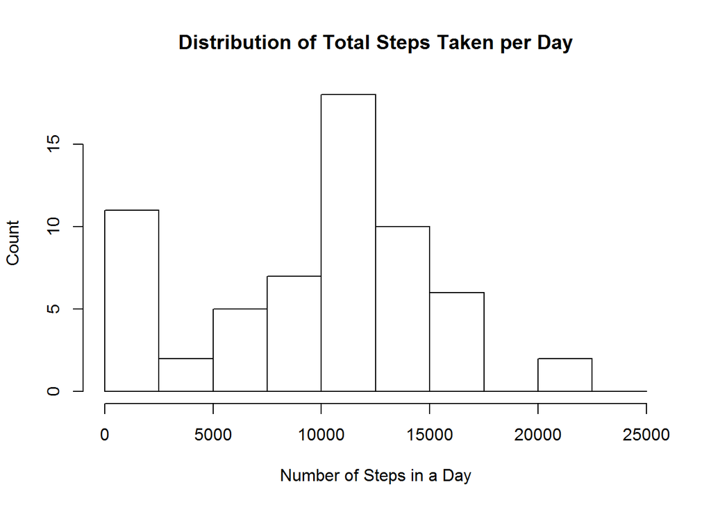

```r
counts=numeric()
n=seq(from=1,to=nrow(data),by=count)
n[nrow(data)/count+1]=nrow(data)+1
for(i in 1:(nrow(data)/count)){
        counts[i]=sum(data$steps[n[i]:(n[i+1]-1)],na.rm=TRUE)

}
hist(counts,main="Distribution of Total Steps Taken per Day",xlab="Number of Steps in a Day",ylab="Count",breaks=seq(from=0,to=25000,by=2500))
```

```r
mean1=format(mean(counts,na.rm=TRUE),digits=0)
median1=format(median(counts,na.rm=TRUE),digits=0,scientific=FALSE)
```

*The **mean** total number of steps taken per day is **9354**. The **median** total number of steps taken per day is **10395**.*

## What is the average daily activity pattern?

The **for loop** in this code chunk iterates through each interval and uses logical indexing to average the steps taken during each interval. **plot.ts** creates a time series plot of the average activity across all days.

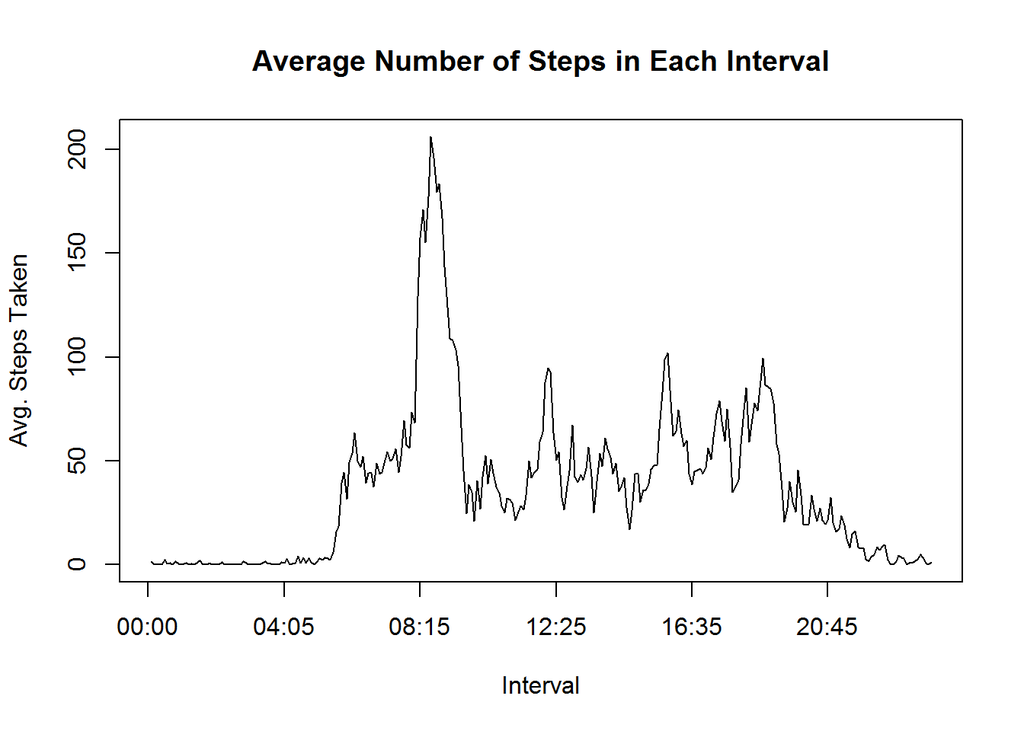

```r
interval=numeric(count)
for(j in 1:count){
        interval[j]=mean(data$steps[data$interval==(data$interval[j])],na.rm=TRUE)
}
plot.ts(interval,main="Average Number of Steps in Each Interval",xlab="Interval",ylab="Avg. Steps Taken",axes=FALSE)
axis(1,at=c(0,50,100,150,200,250),lab=c("00:00","04:05","08:15","12:25","16:35","20:45"))
axis(2)
box()
```

#### Calculating which 5-minute-interval on average has the maximum number of steps.

```r
m=data$interval[match(max(interval),interval)]
```

*On average, the maximum number of steps is on **5-minute-interval 835**.*

## Imputing missing values

#### Calculating the number of missing values.

```r
nas=sum(is.na(data$steps))
```

*The number of missing values is **2304**.*

##### The strategy implemented below for imputing missing values is to set the NA values to the mean number of steps for that 5 minute-interval extracted from *interval*.

This code chunk creates a new data frame and replaces NA values with the mean of that 5-minute interval extracted from **interval**.

```r
new_data=data
for(k in 1:length(new_data$steps)){
        if(is.na(new_data$steps[k])==TRUE){
                if(k%%288 == 0){
                        new_data$steps[k]=interval[288]
                }else{
                        new_data$steps[k]=interval[k%%288]
                }
        }
}
```

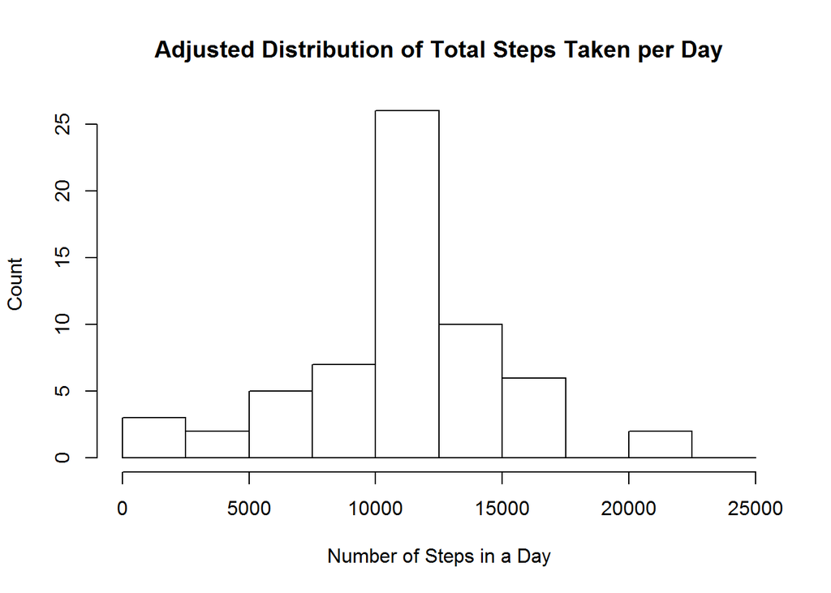

```r
for(i in 1:(nrow(data)/count)){
        counts[i]=sum(new_data$steps[n[i]:(n[i+1]-1)])

}
hist(counts,main="Adjusted Distribution of Total Steps Taken per Day",xlab="Number of Steps in a Day",ylab="Count",breaks=seq(from=0,to=25000,by=2500))
```

```r
mean2=format(mean(counts),digits=0,scientific=FALSE)
median2=format(median(counts),digits=0,scientific=FALSE)
```

## Are there differences in activity patterns between weekdays and weekends?

This code chunk inserts a *Weekday_Weekend* Column in the **new_data** data frame. The **for loop** iterates through **new_data** and marks *weekend* or *weekday* in the new column.

```r
new_data$weekend_weekday=NA
for(j in 1:length(new_data$date)){
        if (weekdays(as.Date(data$date[j])) == "Saturday" | weekdays(as.Date(data$date[j])) == "Sunday"){
                new_data$weekend_weekday[j] = "weekend"
        }else{
                new_data$weekend_weekday[j] = "weekday"
        }
}
```

Casting the *Weekday_Weekend* Column as a factor variable and iterating through **new_data** using logical indexing to compute average steps in weekdays and weekends.

```r
new_data$weekend_weekday=as.factor(new_data$weekend_weekday)

weekend=as.character(new_data$weekend_weekday)=="weekend"
weekday=as.character(new_data$weekend_weekday)=="weekday"
int_wkend=numeric()
int_wkday=numeric()
log_int=logical()

for(j in 1:count){
        log_int=new_data$interval==new_data$interval[j]
        int_wkday[j]=mean(new_data$steps[log_int & weekday])
        int_wkend[j]=mean(new_data$steps[log_int & weekend])
}
```

*plot_data* is a data frame that holds the weekend and weekday average steps data. The *lattice package* is used to create the final time series plot comparing the weekend and weekday average activity.

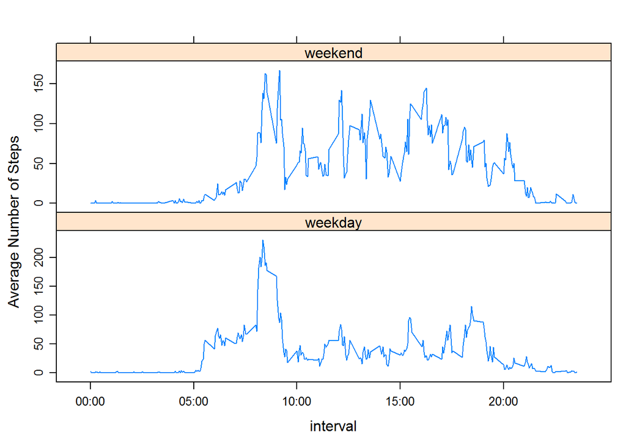

```r
plot_data=data.frame(interval=numeric(count),wkend_wkday=numeric(2*count),factors=factor(2*count))
plot_data$interval=new_data$interval[1:count]
plot_data$wkend_wkday=c(int_wkend,int_wkday)
plot_data$factors=c(rep("weekend",times=count),
                    rep(x="weekday",times=count))
plot_data$factors=as.factor(plot_data$factors)

library(lattice)
xyplot(wkend_wkday~interval|factors,data=plot_data,type="l",
       scales=list(x=list(at=c(0,500,1000,1500,2000),
        labels=c("00:00","05:00","10:00","15:00","20:00")),
        y=list(relation="free")),layout=c(1,2),ylab="Average Number of Steps")
```